# Analyzing Adult Arrest Patterns in New York Counties

Charlie Coun & Miles Gail

GitHub Pages: https://ccoun.github.io

**PROJECT GOALS**

The goal of this project is to analyze adult arrest data across a network of New York State counties to identify relationships between arrest types, geography, time, and several other factors. Specifically, we aim to explore how felony and misdemeanor arrest rates have changed over the years, whether certain counties show disproportionately high rates of drug or violent felonies, and what factors may contribute to these disparities. By examining the breakdown and patterns related to arrest types (both felonies and misdemeanors), we hope to gain a clearer picture of how criminal justice trends vary across New York state. Ultimately, this analysis could provide useful insight into broader social and economic questions surrounding crime.

**Collaboration Plan**

Our team plans to meet at least once a week, on every Sunday, to work on this project to make sure we are staying on track with each milestone. Throughout the week we will communicate by text message and email to document recent work within the collaborative Jupyter notebook, and we will be able to check eachother's changes and progress through the shared Github repository.

```python
import pandas as pd
import numpy as np

# Adult Arrests dataset, sourced directly from the NY State open-data portal
# (NY DCJS, dataset id rikd-mt35). Pulled at runtime so the notebook is self-contained.
df = pd.read_csv('https://data.ny.gov/api/views/rikd-mt35/rows.csv?accessType=DOWNLOAD')
```

**Table 1:**

This dataset, which was sourced from the New York State Division of Criminal Justice Services, tracks adult arrest counts broken down by county, year, and offense type. It can be found at this data.gov site: [DATASET](https://catalog.data.gov/dataset/adult-arrests-18-and-older-by-county-beginning-1970). After reading our main csv dataset into our Jupyter notebook, we can create an initial table to view the variables and the general format of the data. Each row represents a single county in a given year, with columns capturing total arrests as well as breakdowns into felony and misdemeanor subcategories including drug felonies, violent felonies, DWI felonies, other felonies, drug misdemeanors, DWI misdemeanors, property misdemeanors, and other misdemeanors.

```python
df.head()
```

|  | County | Year | Total | Felony Total | Drug Felony | Violent Felony | DWI Felony | Other Felony | Misdemeanor Total | Drug Misdemeanor | DWI Misdemeanor | Property Misdemeanor | Other Misdemeanor |
| --- | --- | --- | --- | --- | --- | --- | --- | --- | --- | --- | --- | --- | --- |
| 0 | Albany | 1970 | 1032 | 563 | 90 | 155 | 4 | 314 | 469 | 179 | 47 | 73 | 170 |
| 1 | Albany | 1971 | 1566 | 693 | 119 | 199 | 6 | 369 | 873 | 179 | 111 | 210 | 373 |
| 2 | Albany | 1972 | 2604 | 864 | 181 | 215 | 8 | 460 | 1740 | 251 | 295 | 417 | 777 |
| 3 | Albany | 1973 | 3055 | 955 | 213 | 230 | 28 | 484 | 2100 | 298 | 491 | 506 | 805 |
| 4 | Albany | 1974 | 3587 | 1070 | 225 | 244 | 17 | 584 | 2517 | 354 | 610 | 670 | 883 |

# Data Tidying

Before we analyze possible patterns in the data, we need to make sure our dataset is properly formatted and ready to use. First, we check that the variables have the correct types, which they already do. Since County represents named labels it makes sense it is read as object, and every other variable is read as int64 as they represent whole number counts.

```python
df.dtypes
```

|  | 0 |
| --- | --- |
| County | object |
| Year | int64 |
| Total | int64 |
| Felony Total | int64 |
| Drug Felony | int64 |
| Violent Felony | int64 |
| DWI Felony | int64 |
| Other Felony | int64 |
| Misdemeanor Total | int64 |
| Drug Misdemeanor | int64 |
| DWI Misdemeanor | int64 |
| Property Misdemeanor | int64 |
| Other Misdemeanor | int64 |

**dtype:** object

Next, we check if there are any missing values, which there are not.

```python
df.isnull().sum()
```

|  | 0 |
| --- | --- |
| County | 0 |
| Year | 0 |
| Total | 0 |
| Felony Total | 0 |
| Drug Felony | 0 |
| Violent Felony | 0 |
| DWI Felony | 0 |
| Other Felony | 0 |
| Misdemeanor Total | 0 |
| Drug Misdemeanor | 0 |
| DWI Misdemeanor | 0 |
| Property Misdemeanor | 0 |
| Other Misdemeanor | 0 |

**dtype:** int64

Since we will be utilizing all variables in the data, we do not need to remove or add any yet. But, we will rename Felony Total and Misdemeanor Total so that their titles better match with the formatting of the other variables. When all other crime variables are in the format 'Type Category' (Drug Felony, Violent Felony, DWI Misdemeanor), having Total Felony and Total Misdemeanor keeps the naming convention consistent and easy to understand.

```python
df = df.rename(columns={
    'Felony Total': 'Total Felony',
    'Misdemeanor Total': 'Total Misdemeanor'
})
```

We can recheck the names of the variables to make sure they have been renamed correctly.

```python
print(df.columns.tolist())
```

```
['County', 'Year', 'Total', 'Total Felony', 'Drug Felony', 'Violent Felony', 'DWI Felony', 'Other Felony', 'Total Misdemeanor', 'Drug Misdemeanor', 'DWI Misdemeanor', 'Property Misdemeanor', 'Other Misdemeanor']
```

# Exploratory Data Analysis

Below we compute 5 summary statistics to begin understanding the shape and trends in the data, followed by a visualization of statewide arrest trends over time.

```python
#1. Total arrests across all counties and years
print("1. Total arrests in dataset:", df['Total'].sum())

#2. Average total arrests per county per year
print("2. Avg arrests per county/year:", round(df['Total'].mean(), 1))

#3. County with highest all-time total arrests
top_county = df.groupby('County')['Total'].sum().idxmax()
top_val = df.groupby('County')['Total'].sum().max()
print(f"3. County with most total arrests: {top_county} ({top_val:,})")

#4. Year with highest statewide arrests
yearly = df.groupby('Year')['Total'].sum()
peak_year = yearly.idxmax()
print(f"4. Year with most statewide arrests: {peak_year} ({yearly[peak_year]:,})")

#5. Felony vs misdemeanor split (statewide average %)
felony_pct = (df['Total Felony'].sum() / df['Total'].sum()) * 100
misd_pct = (df['Total Misdemeanor'].sum() / df['Total'].sum()) * 100
print(f"5. Statewide felony rate: {felony_pct:.1f}% | misdemeanor rate: {misd_pct:.1f}%")
```

```
1. Total arrests in dataset: 22743213
2. Avg arrests per county/year: 6550.5
3. County with most total arrests: New York (4,185,401)
4. Year with most statewide arrests: 1998 (542,981)
5. Statewide felony rate: 34.5% | misdemeanor rate: 65.5%
```

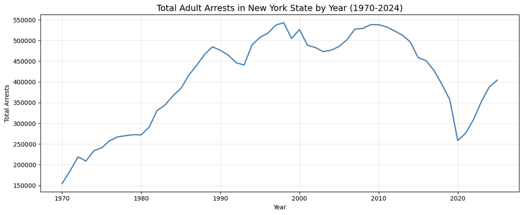

```python
import matplotlib.pyplot as plt

#Figure 1
#Line chart: statewide total arrests by year
yearly_totals = df.groupby('Year')['Total'].sum()
plt.figure(figsize=(12, 5))
plt.plot(yearly_totals.index, yearly_totals.values, color='steelblue', linewidth=2)
plt.title('Total Adult Arrests in New York State by Year (1970-2024)', fontsize=14)
plt.xlabel('Year')
plt.ylabel('Total Arrests')
plt.grid(True, alpha=0.3)
plt.tight_layout()
```

**Figure 1:**

# Dataset 2: HPI Per County

```python
# House Price Index dataset, downloaded directly from the FHFA at runtime so the
# notebook is self-contained. The file has 5 rows of header text before the column
# headers, so we skip them.
df2 = pd.read_excel('https://www.fhfa.gov/hpi/download/annual/hpi_at_county.xlsx', skiprows=5)
```

Here we import our second dataset, HPI per counties. This dataset, sourced from the Federal Housing Finance Agency (FHFA), tracks the House Price Index (HPI) for counties across the United States, measuring cumulative nominal annual appreciation in single-family home values over time. It can be found at the FHFA's official datasets page: [DATASET2](https://www.fhfa.gov/data/hpi/datasets?tab=annual-data). Because the file contains five rows of descriptive header text before the actual column names, we used the skiprows=5 parameter to load the data cleanly. Each row represents a county in a given year, with columns giving the State, County Name, FIPS Code, Year, Annual Change in Home Prices as a Percentage, and three variations of the HPI: one indexed to the county's first recorded year, one with a base of 100 in 1990, and one with a base of 100 in 2000.

```python
df2.head()
```

|  | State | County | FIPS code | Year | Annual Change (%) | HPI | HPI with 1990 base | HPI with 2000 base |
| --- | --- | --- | --- | --- | --- | --- | --- | --- |
| 0 | AL | Autauga | 1001 | 1986 | NaN | 100.00 | 95.45 | 70.53 |
| 1 | AL | Autauga | 1001 | 1987 | -2.14 | 97.86 | 93.40 | 69.02 |
| 2 | AL | Autauga | 1001 | 1988 | 4.00 | 101.77 | 97.14 | 71.79 |
| 3 | AL | Autauga | 1001 | 1989 | 3.53 | 105.37 | 100.57 | 74.32 |
| 4 | AL | Autauga | 1001 | 1990 | -0.57 | 104.77 | 100.00 | 73.90 |

# Data Tidying

Again, to make sure the data is properly formatted and ready to use, we check that the variables have the correct types, which they already do. Since State and County represent named labels it makes sense they are read as objects, matching the County variable from the first dataset, and every other variable is read as int64 or float64 as they represent whole number or integer counts.

```python
df2.dtypes
```

|  | 0 |
| --- | --- |
| State | object |
| County | object |
| FIPS code | int64 |
| Year | int64 |
| Annual Change (%) | float64 |
| HPI | float64 |
| HPI with 1990 base | float64 |
| HPI with 2000 base | float64 |

**dtype:** object

Since this project if focusing on New York specific counties, the rest of the counties from other states must be removed.

```python
df2 = df2[df2['State'] == 'NY']
df2['State'].unique()
```

```
array(['NY'], dtype=object)
```

```python
print(df['Year'].min(), df['Year'].max())
print(df2['Year'].min(), df2['Year'].max())

df1 = df[df['Year'] >= 1975]
df2 = df2[df2['Year'] <= 2024]
```

```
1970 2025
1975 2025
```

The same process must be done for County names to find the overlap of the two datasets and make sure they match. First, the county names in each are compared and we find the counties that appear one set but not the other. It turns out the counties all match, except for the spelling of 'St. Lawrence', so this is changed in the HPI dataset to match the arrest formatting.

```python
counties1 = set(df['County'].unique())
counties2 = set(df2['County'].unique())

print("In arrests but not HPI:", counties1 - counties2)
print("In HPI but not arrests:", counties2 - counties1)

df2['County'] = df2['County'].replace('Saint Lawrence', 'St. Lawrence')
```

```
In arrests but not HPI: {'St. Lawrence'}
In HPI but not arrests: {'Saint Lawrence'}
```

Next, we check if there are any missing values in our second dataset, which we see that there are.

```python
print(df2.isnull().sum())

null_rows = df2[df2['Annual Change (%)'].isna()]
print(null_rows[['County', 'Year']])
```

```
State                   0
County                  0
FIPS code               0
Year                    0
Annual Change (%)      84
HPI                    16
HPI with 1990 base    297
HPI with 2000 base     75
dtype: int64
            County  Year
62026       Albany  1975
62077     Allegany  1987
62116        Bronx  1976
62166       Broome  1975
62217  Cattaraugus  1986
...            ...   ...
64497   Washington  1986
64537        Wayne  1978
64585  Westchester  1975
64636      Wyoming  1986
64676        Yates  1986

[84 rows x 2 columns]
```

```python
df2 = df2.drop(columns=['HPI with 1990 base', 'HPI with 2000 base'])

df2 = df2.sort_values(['County', 'Year'])
df2['Annual Change (%)'] = df2.groupby('County')['Annual Change (%)'].transform(lambda x: x.interpolate().bfill())
df2['HPI'] = df2.groupby('County')['HPI'].transform(lambda x: x.interpolate())
print(df2.isnull().sum())
```

```
State                0
County               0
FIPS code            0
Year                 0
Annual Change (%)    0
HPI                  0
dtype: int64
```

# Exploratory Data Analysis

Below we compute a couple summary statistics for the second dataset, followed by visualizations of HPI across counties over time and the top 5 counties by HPI.

```python
#Stat 1: County with highest average HPI
top_hpi_county = df2.groupby('County')['HPI'].mean().idxmax()
top_hpi_val = df2.groupby('County')['HPI'].mean().max()
print(f"County with highest avg HPI: {top_hpi_county} ({top_hpi_val:.1f})")

#Stat 2: Year with highest average statewide HPI
peak_hpi_year = df2.groupby('Year')['HPI'].mean().idxmax()
peak_hpi_val = df2.groupby('Year')['HPI'].mean().max()
print(f"Year with highest avg HPI statewide: {peak_hpi_year} ({peak_hpi_val:.1f})")
```

```
County with highest avg HPI: Kings (988.9)
Year with highest avg HPI statewide: 2024 (663.5)
```

Examining HPI patterns across the New York counties, Kings County (Brooklyn) has the highest average HPI at 988.9, reflecting the dramatic appreciation of Brooklyn home values over the 1975-2024 window. Statewide, the most recent year in the dataset, 2024, also recorded the highest average HPI at 663.5, indicating that house prices in NY have been on a long-run upward trajectory and have continued to climb in the years following the pandemic. Together these two stats hint that any relationship between housing prices and arrest activity will likely be confounded by year and by county-level urban density, both of which we will need to control for in later modeling.

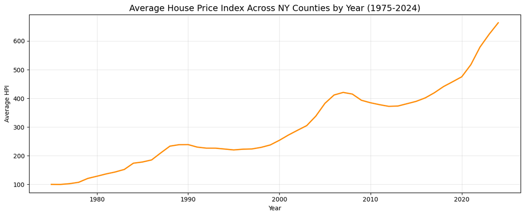

```python
#Figure 2
#Line chart: Average HPI across all NY counties over time
avg_hpi_yearly = df2.groupby('Year')['HPI'].mean()
plt.figure(figsize=(12, 5))
plt.plot(avg_hpi_yearly.index, avg_hpi_yearly.values, color='darkorange', linewidth=2)
plt.title('Average House Price Index Across NY Counties by Year (1975-2024)', fontsize=14)
plt.xlabel('Year')
plt.ylabel('Average HPI')
plt.grid(True, alpha=0.3)
plt.tight_layout()
```

**Figure 2:**

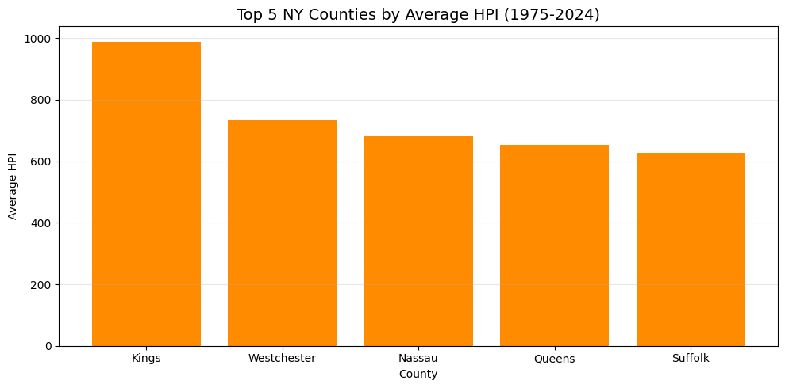

```python
#Figure 3
#Bar chart: Top 5 counties by average HPI
top5_hpi = df2.groupby('County')['HPI'].mean().nlargest(5)
plt.figure(figsize=(10, 5))
plt.bar(top5_hpi.index, top5_hpi.values, color='darkorange')
plt.title('Top 5 NY Counties by Average HPI (1975-2024)', fontsize=14)
plt.xlabel('County')
plt.ylabel('Average HPI')
plt.grid(True, alpha=0.3, axis='y')
plt.tight_layout()
```

**Figure 3:**

We then merge the two datasets together so that we can investigate specific summary statistcs and charts that include all the data, as well as start to formulate the final model we will build.

```python
df_merged = pd.merge(df1, df2[['County', 'Year', 'HPI', 'Annual Change (%)']], on=['County', 'Year'])
```

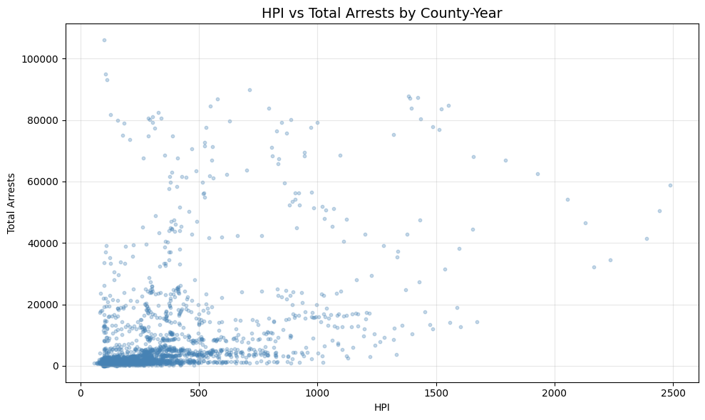

```python
#Figure 4
#Scatter plot: HPI vs total arrests
plt.figure(figsize=(10, 6))
plt.scatter(df_merged['HPI'], df_merged['Total'], alpha=0.3, color='steelblue', s=10)
plt.title('HPI vs Total Arrests by County-Year', fontsize=14)
plt.xlabel('HPI')
plt.ylabel('Total Arrests')
plt.grid(True, alpha=0.3)
plt.tight_layout()
```

**Figure 4:**

This scatter plot shows HPI against total arrests at the county-year level after the two datasets are merged. The bulk of the points cluster in the low-HPI / low-arrest corner, but a long tail of high-arrest county-years extends out to the right, corresponding mostly to NYC boroughs in their high-HPI later years. The relationship is clearly non-linear and visually noisy, which suggests that a simple bivariate correlation will not tell the full story - we will likely need to log-transform arrests, control for population, or include county and year fixed effects in our model in order to recover any real signal.

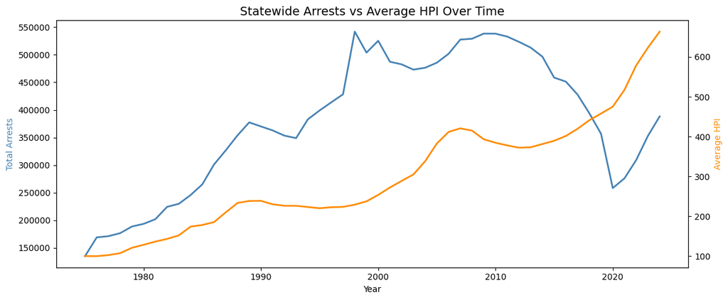

```python
#Figure 5
#Dual Line Chart: Statewide arrests vs avg HPI over time
yearly_arrests = df_merged.groupby('Year')['Total'].sum()
yearly_hpi = df_merged.groupby('Year')['HPI'].mean()

fig, ax1 = plt.subplots(figsize=(12, 5))
ax1.plot(yearly_arrests.index, yearly_arrests.values, color='steelblue', linewidth=2, label='Total Arrests')
ax1.set_xlabel('Year')
ax1.set_ylabel('Total Arrests', color='steelblue')

ax2 = ax1.twinx()
ax2.plot(yearly_hpi.index, yearly_hpi.values, color='darkorange', linewidth=2, label='Avg HPI')
ax2.set_ylabel('Average HPI', color='darkorange')

plt.title('Statewide Arrests vs Average HPI Over Time', fontsize=14)
fig.tight_layout()
```

**Figure 5:**

# Model Plans

**Model 1 - Hypothesis test on the HPI / arrest-rate relationship.** We will test whether there is a statistically significant relationship between county-level HPI and arrest rates after controlling for time and county. The *dependent variable* is total arrests per county-year (and, in follow-up specifications, Total Felony, Violent Felony, and Drug Felony arrests). The primary *independent variable* is HPI, with annual percent change in HPI included as an additional regressor. We will fit a linear regression with county and year fixed effects (a within-county estimator) and report the coefficient on HPI along with its t-statistic and p-value. The null hypothesis is that, conditional on county and year, HPI has no association with arrest rates; rejecting it would suggest that local housing-market conditions move with local crime in a way that is not just a shared time trend or a fixed level difference between counties. Figures 4 and 5 motivate this directly: they show suggestive co-movement at the aggregate level, but they also make it obvious that controls are required before any conclusion can be drawn.

```python
# Run this cell AFTER "Runtime > Run all" finishes, so the rest of the
# notebook's outputs are present. Approve the Drive permission popup
# when it appears.
from google.colab import drive
drive.mount('/content/drive')

# Force a save of the current notebook (with outputs) to Drive,
# then run nbconvert against the saved .ipynb on Drive.
from IPython.display import display, Javascript
display(Javascript('google.colab.notebook.save()'))

import time
time.sleep(8)  # give Colab a moment to flush the save

import subprocess
out = subprocess.run([
    'jupyter', 'nbconvert', '--to', 'html',
    '/content/drive/MyDrive/FinalProject_milestone2_FINAL.ipynb',
    '--output', 'index.html',
    '--output-dir', '/content',
], capture_output=True, text=True)
print('STDOUT:', out.stdout)
print('STDERR:', out.stderr)
print('Return code:', out.returncode)
```